# Day 2 - Case Introduction

09/05/2018

## The Case

## Case Company

- "Santander Cycles" (government-run)
- Sponsored by Santander, Private Banking, [37th largest corporation world-wide](https://en.wikipedia.org/wiki/Banco_Santander)
- Record: 73.000 bike rentals in a day

[figure not shown]

## The Problem

- **Staffing the correct number of bikes**
- Minimise outdoor time to
  - reduce operating costs (electricity)
  - decrease weather teardown and exposure to vandalism
  - undertake maintenance
- Maximise availability as not never under-staff
  - valuability of the service is heavily dependent on availability
  - non-availability is causing churn
  - non-availability is decreasing profits

## The Value

- Correctly forecasting demand, especially spikes
  - retains customers
  - maximises profit
  - minimises costs

## The Data

Dataset: `data/tfl-daily-cycle-hires.csv` [(Source)](https://data.london.gov.uk/dataset/number-bicycle-hires)

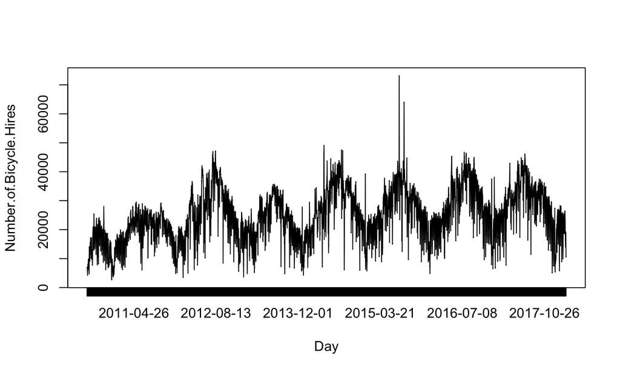

```r
data = read.csv('data/tfl-daily-cycle-hires.csv')
plot(data)
lines(data)
```

## Tasks

- Load and plot data
- Inspect data: decide whether or not to make stationary or not (via `log()`)
- Prepare dataframe for `prophet` (Rename its columns to `ds`, `y`)
- Create dataframe for `holidays` from
  - `UK_holidays.csv` and
  - `UK_tube-strikes.csv`
- Predict next 365 days
  - plot prediction
  - plot components

## Tasks

- Interpret prediction - describe
  - patterns (yearly/weekly seasonality)
  - effect of bank holidays/tube strikes
  - trend
  - peaks/bottoms
- Cross-validate prediction
- Describe business implications of your forecast

## Report template

- Find template here: https://docs.google.com/document/d/1aoafDiWn9C3wXNbwMaCqiQiCpOhsCYDeqdAYim_9-Gw
- Write 3 pages report, including **all** of the above tasks
- Present your findings in **10-minute** presentation on Friday
- Find the solution code in `data/prophet-bikehires.R`
- I answer questions on the slack channel `#predictive-analytics`

## Literature

- [Forecasting: Principles and Practice](https://otexts.org/fpp2/)
- [Facebook Prophet](https://facebook.github.io/prophet/)